# Intro to Visualization with ggplot2

### Geomtry

Geometry describes the ways that data points can be visualized

#### One variable

Some geometries only work with one of `x` or `y` passed to `aes`. Let’s use `len`

```r
p_len =  ggplot(ToothGrowth, aes(x = len, fill = supp))
```

`geom_histogram` generates a histogram. If a categorical variable is assigned to the mapping (e.g. `fill`) it will be accounted for in the representation.

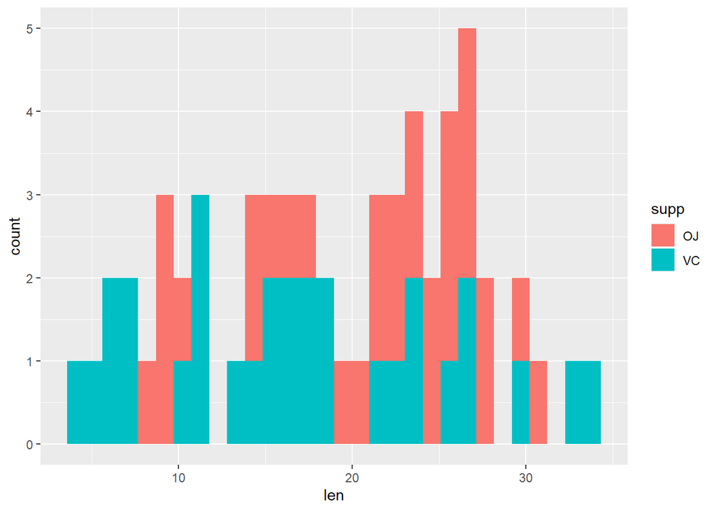

```r
p_len + geom_histogram()
```

`geom_density` generates what is essentially a smoothed histogram.We’re going to want to set the `alpha` parameter of `geom_density` to a value less than 1 (say, .5) to lower the opacity of the filled curves so both distributions become visible.

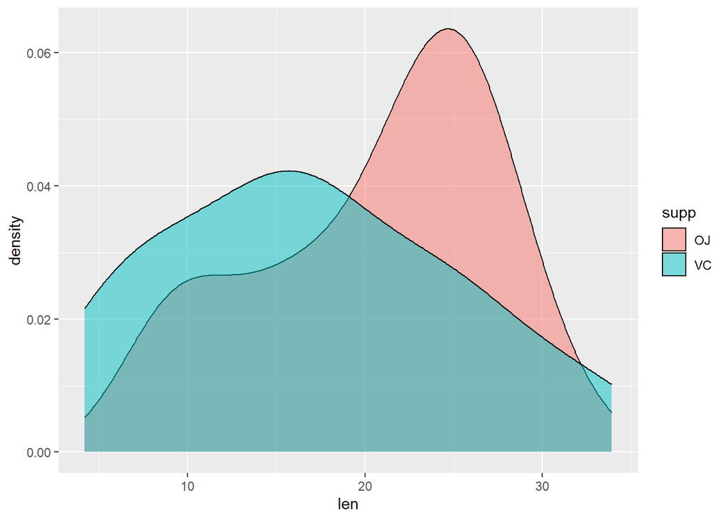

```r
p_len + geom_density(alpha = .5)
```

`geom_dotplot`generates a traditional dotplot, very similar to the histogram function.

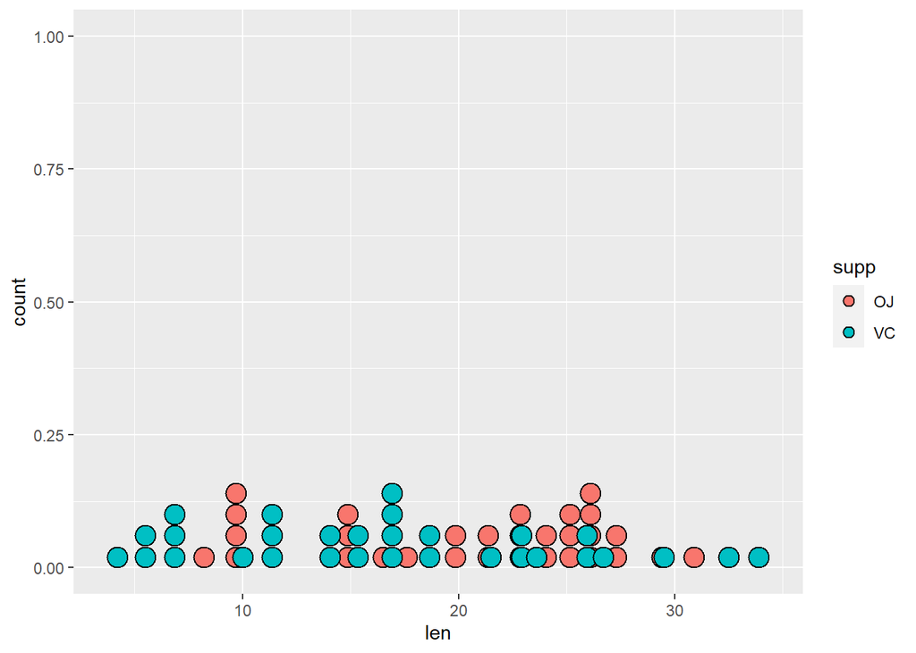

```r
p_len + geom_dotplot()
```